# Risk Factor Analysis

## Outcome Variable

**Outcome Variable:** stunted

## Predictor Variables

**Intervention Variable:** gagebrth

**Adjustment Set:**

- arm
- sex
- W_mage
- meducyrs
- feducyrs
- hhwealth_quart
- W_nrooms
- brthmon
- W_parity
- impsan
- delta_W_mage
- delta_meducyrs
- delta_feducyrs
- delta_hhwealth_quart
- delta_W_nrooms
- delta_brthmon
- delta_W_parity
- delta_impsan

## Stratifying Variables

The analysis was stratified on these variable(s):

- agecat
- studyid
- country

## Data Summary

| agecat | studyid | country | gagebrth | stunted | n_cell | n |
| --- | --- | --- | --- | --- | --- | --- |
| Birth | ki1000108-CMC-V-BCS-2002 | INDIA | Full or late term | 0 | 48 | 92 |
| Birth | ki1000108-CMC-V-BCS-2002 | INDIA | Full or late term | 1 | 10 | 92 |
| Birth | ki1000108-CMC-V-BCS-2002 | INDIA | Preterm | 0 | 8 | 92 |
| Birth | ki1000108-CMC-V-BCS-2002 | INDIA | Preterm | 1 | 3 | 92 |
| Birth | ki1000108-CMC-V-BCS-2002 | INDIA | Early term | 0 | 19 | 92 |
| Birth | ki1000108-CMC-V-BCS-2002 | INDIA | Early term | 1 | 4 | 92 |
| Birth | ki1000108-IRC | INDIA | Full or late term | 0 | 211 | 369 |
| Birth | ki1000108-IRC | INDIA | Full or late term | 1 | 27 | 369 |
| Birth | ki1000108-IRC | INDIA | Preterm | 0 | 27 | 369 |
| Birth | ki1000108-IRC | INDIA | Preterm | 1 | 9 | 369 |
| Birth | ki1000108-IRC | INDIA | Early term | 0 | 87 | 369 |
| Birth | ki1000108-IRC | INDIA | Early term | 1 | 8 | 369 |
| Birth | ki1000109-EE | PAKISTAN | Full or late term | 0 | 6 | 240 |
| Birth | ki1000109-EE | PAKISTAN | Full or late term | 1 | 5 | 240 |
| Birth | ki1000109-EE | PAKISTAN | Preterm | 0 | 108 | 240 |
| Birth | ki1000109-EE | PAKISTAN | Preterm | 1 | 74 | 240 |
| Birth | ki1000109-EE | PAKISTAN | Early term | 0 | 26 | 240 |
| Birth | ki1000109-EE | PAKISTAN | Early term | 1 | 21 | 240 |
| Birth | ki1017093c-NIH-Crypto | BANGLADESH | Full or late term | 0 | 150 | 732 |
| Birth | ki1017093c-NIH-Crypto | BANGLADESH | Full or late term | 1 | 12 | 732 |
| Birth | ki1017093c-NIH-Crypto | BANGLADESH | Preterm | 0 | 193 | 732 |
| Birth | ki1017093c-NIH-Crypto | BANGLADESH | Preterm | 1 | 64 | 732 |
| Birth | ki1017093c-NIH-Crypto | BANGLADESH | Early term | 0 | 288 | 732 |
| Birth | ki1017093c-NIH-Crypto | BANGLADESH | Early term | 1 | 25 | 732 |
| Birth | ki1101329-Keneba | GAMBIA | Full or late term | 0 | 712 | 1515 |
| Birth | ki1101329-Keneba | GAMBIA | Full or late term | 1 | 22 | 1515 |
| Birth | ki1101329-Keneba | GAMBIA | Preterm | 0 | 200 | 1515 |
| Birth | ki1101329-Keneba | GAMBIA | Preterm | 1 | 35 | 1515 |
| Birth | ki1101329-Keneba | GAMBIA | Early term | 0 | 521 | 1515 |
| Birth | ki1101329-Keneba | GAMBIA | Early term | 1 | 25 | 1515 |

[output cut: 162 more lines]

The following strata were considered:

- agecat: 24 months, studyid: ki1000108-CMC-V-BCS-2002, country: INDIA
- agecat: 24 months, studyid: ki1000108-IRC, country: INDIA
- agecat: 24 months, studyid: ki1000109-EE, country: PAKISTAN
- agecat: 24 months, studyid: ki1017093c-NIH-Crypto, country: BANGLADESH
- agecat: 24 months, studyid: ki1066203-TanzaniaChild2, country: TANZANIA, UNITED REPUBLIC OF
- agecat: 24 months, studyid: ki1101329-Keneba, country: GAMBIA
- agecat: 24 months, studyid: ki1119695-PROBIT, country: BELARUS
- agecat: 24 months, studyid: ki1135781-COHORTS, country: GUATEMALA
- agecat: 24 months, studyid: ki1135781-COHORTS, country: INDIA
- agecat: 24 months, studyid: ki1135781-COHORTS, country: PHILIPPINES
- agecat: 24 months, studyid: kiGH5241-JiVitA-3, country: BANGLADESH
- agecat: 6 months, studyid: ki1000108-CMC-V-BCS-2002, country: INDIA
- agecat: 6 months, studyid: ki1000108-IRC, country: INDIA
- agecat: 6 months, studyid: ki1000109-EE, country: PAKISTAN
- agecat: 6 months, studyid: ki1017093c-NIH-Crypto, country: BANGLADESH
- agecat: 6 months, studyid: ki1066203-TanzaniaChild2, country: TANZANIA, UNITED REPUBLIC OF
- agecat: 6 months, studyid: ki1101329-Keneba, country: GAMBIA
- agecat: 6 months, studyid: ki1119695-PROBIT, country: BELARUS
- agecat: 6 months, studyid: ki1135781-COHORTS, country: GUATEMALA
- agecat: 6 months, studyid: ki1135781-COHORTS, country: INDIA
- agecat: 6 months, studyid: ki1135781-COHORTS, country: PHILIPPINES
- agecat: 6 months, studyid: kiGH5241-JiVitA-3, country: BANGLADESH
- agecat: Birth, studyid: ki1000108-CMC-V-BCS-2002, country: INDIA
- agecat: Birth, studyid: ki1000108-IRC, country: INDIA
- agecat: Birth, studyid: ki1000109-EE, country: PAKISTAN
- agecat: Birth, studyid: ki1017093c-NIH-Crypto, country: BANGLADESH
- agecat: Birth, studyid: ki1101329-Keneba, country: GAMBIA
- agecat: Birth, studyid: ki1119695-PROBIT, country: BELARUS
- agecat: Birth, studyid: ki1135781-COHORTS, country: GUATEMALA
- agecat: Birth, studyid: ki1135781-COHORTS, country: INDIA
- agecat: Birth, studyid: ki1135781-COHORTS, country: PHILIPPINES
- agecat: Birth, studyid: kiGH5241-JiVitA-3, country: BANGLADESH

### Dropped Strata

Some strata were dropped due to rare outcomes:

- agecat: Birth, studyid: ki1000108-CMC-V-BCS-2002, country: INDIA
- agecat: 6 months, studyid: ki1000109-EE, country: PAKISTAN
- agecat: 24 months, studyid: ki1000109-EE, country: PAKISTAN
- agecat: 24 months, studyid: ki1066203-TanzaniaChild2, country: TANZANIA, UNITED REPUBLIC OF

## Methods Detail

We’re interested in the causal parameters $E[Y_a]$ for all values of $a \in \mathcal{A}$. These parameters represent the mean outcome if, possibly contrary to fact, we intervened to set all units to have $A=a$. Under the randomization and positivity assumptions, these are identified by the statistical parameters $\psi_a=E_W[E_{Y|A,W}(Y|A=a,W)]$. In addition, we’re interested in the mean of $Y$, $E[Y]$ under no intervention (the observed mean). We will estimate these parameters by using SuperLearner to fit the relevant likelihood factors – $E_{Y|A,W}(Y|A=a,W)$ and $p(A=a|W)$, and then updating our likelihood fit using a joint TMLE.

For unadjusted analyses ($W=\{\}$), initial likelihoods were estimated using Lrnr_glm to estimate the simple $E(Y|A)$ and Lrnr_mean to estimate $p(A)$. For adjusted analyses, a small library containing Lrnr_glmnet, Lrnr_xgboost, and Lrnr_mean was used.

Having estimated these parameters, we will then use the delta method to estimate relative risks and attributable risks relative to a prespecified baseline level of $A$.

# Results Detail

## Results Plots

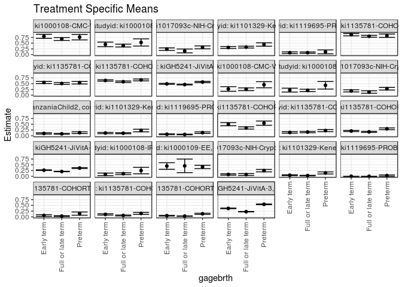

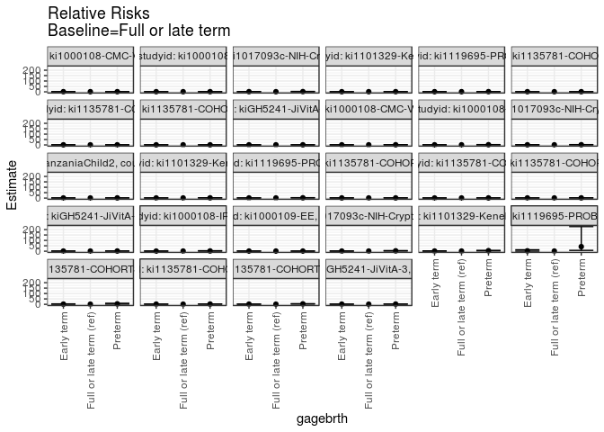

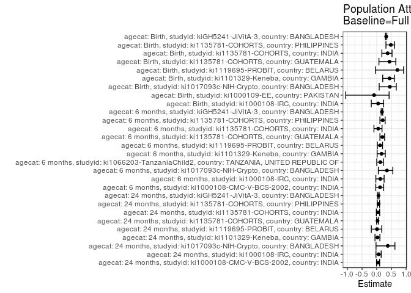

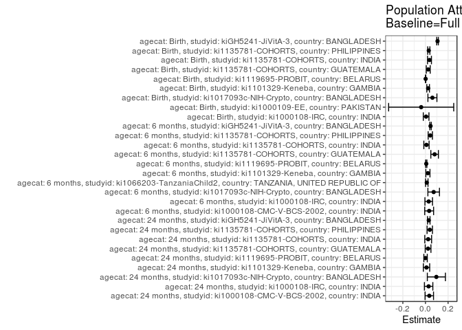

## Results Table

### Parameter: TSM

| agecat | studyid | country | intervention_level | baseline_level | estimate | ci_lower | ci_upper |
| --- | --- | --- | --- | --- | --- | --- | --- |
| Birth | ki1000108-IRC | INDIA | Full or late term | NA | 0.1134454 | 0.0730999 | 0.1537909 |
| Birth | ki1000108-IRC | INDIA | Preterm | NA | 0.2500000 | 0.1083597 | 0.3916403 |
| Birth | ki1000108-IRC | INDIA | Early term | NA | 0.0842105 | 0.0282919 | 0.1401292 |
| Birth | ki1000109-EE | PAKISTAN | Full or late term | NA | 0.4545455 | 0.1596783 | 0.7494126 |
| Birth | ki1000109-EE | PAKISTAN | Preterm | NA | 0.4065934 | 0.3350820 | 0.4781048 |
| Birth | ki1000109-EE | PAKISTAN | Early term | NA | 0.4468085 | 0.3043776 | 0.5892394 |
| Birth | ki1017093c-NIH-Crypto | BANGLADESH | Full or late term | NA | 0.0764226 | 0.0352322 | 0.1176131 |
| Birth | ki1017093c-NIH-Crypto | BANGLADESH | Preterm | NA | 0.2456257 | 0.1926094 | 0.2986421 |
| Birth | ki1017093c-NIH-Crypto | BANGLADESH | Early term | NA | 0.0800882 | 0.0499024 | 0.1102741 |
| Birth | ki1101329-Keneba | GAMBIA | Full or late term | NA | 0.0304694 | 0.0180830 | 0.0428559 |
| Birth | ki1101329-Keneba | GAMBIA | Preterm | NA | 0.1460056 | 0.1010761 | 0.1909351 |
| Birth | ki1101329-Keneba | GAMBIA | Early term | NA | 0.0460020 | 0.0285129 | 0.0634910 |
| Birth | ki1119695-PROBIT | BELARUS | Full or late term | NA | 0.0007044 | -0.0002055 | 0.0016144 |
| Birth | ki1119695-PROBIT | BELARUS | Preterm | NA | 0.0296610 | -0.0004610 | 0.0597831 |
| Birth | ki1119695-PROBIT | BELARUS | Early term | NA | 0.0022152 | 0.0011581 | 0.0032723 |
| Birth | ki1135781-COHORTS | GUATEMALA | Full or late term | NA | 0.0322589 | 0.0132412 | 0.0512766 |
| Birth | ki1135781-COHORTS | GUATEMALA | Preterm | NA | 0.1411206 | 0.0711919 | 0.2110494 |
| Birth | ki1135781-COHORTS | GUATEMALA | Early term | NA | 0.0602398 | 0.0250571 | 0.0954224 |
| Birth | ki1135781-COHORTS | INDIA | Full or late term | NA | 0.0603212 | 0.0408889 | 0.0797536 |
| Birth | ki1135781-COHORTS | INDIA | Preterm | NA | 0.1493788 | 0.1077308 | 0.1910267 |
| Birth | ki1135781-COHORTS | INDIA | Early term | NA | 0.1071575 | 0.0781371 | 0.1361780 |
| Birth | ki1135781-COHORTS | PHILIPPINES | Full or late term | NA | 0.0317331 | 0.0218004 | 0.0416659 |
| Birth | ki1135781-COHORTS | PHILIPPINES | Preterm | NA | 0.1330330 | 0.1068453 | 0.1592207 |
| Birth | ki1135781-COHORTS | PHILIPPINES | Early term | NA | 0.0505932 | 0.0382401 | 0.0629464 |
| Birth | kiGH5241-JiVitA-3 | BANGLADESH | Full or late term | NA | 0.2246589 | 0.2153492 | 0.2339687 |
| Birth | kiGH5241-JiVitA-3 | BANGLADESH | Preterm | NA | 0.5449697 | 0.5285802 | 0.5613592 |
| Birth | kiGH5241-JiVitA-3 | BANGLADESH | Early term | NA | 0.3676641 | 0.3538595 | 0.3814686 |
| 6 months | ki1000108-CMC-V-BCS-2002 | INDIA | Full or late term | NA | 0.2583652 | 0.1989140 | 0.3178164 |
| 6 months | ki1000108-CMC-V-BCS-2002 | INDIA | Preterm | NA | 0.4542910 | 0.3208006 | 0.5877815 |
| 6 months | ki1000108-CMC-V-BCS-2002 | INDIA | Early term | NA | 0.2707291 | 0.1714917 | 0.3699665 |

[output cut: 54 more lines]

### Parameter: E(Y)

| agecat | studyid | country | intervention_level | baseline_level | estimate | ci_lower | ci_upper |
| --- | --- | --- | --- | --- | --- | --- | --- |
| Birth | ki1000108-IRC | INDIA | NA | NA | 0.1192412 | 0.0861307 | 0.1523517 |
| Birth | ki1000109-EE | PAKISTAN | NA | NA | 0.4166667 | 0.3541635 | 0.4791698 |
| Birth | ki1017093c-NIH-Crypto | BANGLADESH | NA | NA | 0.1379781 | 0.1129774 | 0.1629789 |
| Birth | ki1101329-Keneba | GAMBIA | NA | NA | 0.0541254 | 0.0427281 | 0.0655227 |
| Birth | ki1119695-PROBIT | BELARUS | NA | NA | 0.0023758 | 0.0010936 | 0.0036580 |
| Birth | ki1135781-COHORTS | GUATEMALA | NA | NA | 0.0567261 | 0.0384591 | 0.0749931 |
| Birth | ki1135781-COHORTS | INDIA | NA | NA | 0.0959010 | 0.0798450 | 0.1119570 |
| Birth | ki1135781-COHORTS | PHILIPPINES | NA | NA | 0.0611772 | 0.0526341 | 0.0697204 |
| Birth | kiGH5241-JiVitA-3 | BANGLADESH | NA | NA | 0.3315456 | 0.3240495 | 0.3390416 |
| 6 months | ki1000108-CMC-V-BCS-2002 | INDIA | NA | NA | 0.2910663 | 0.2432023 | 0.3389303 |
| 6 months | ki1000108-IRC | INDIA | NA | NA | 0.2371134 | 0.1947393 | 0.2794875 |
| 6 months | ki1017093c-NIH-Crypto | BANGLADESH | NA | NA | 0.2097902 | 0.1799252 | 0.2396552 |
| 6 months | ki1066203-TanzaniaChild2 | TANZANIA, UNITED REPUBLIC OF | NA | NA | 0.0956385 | 0.0824215 | 0.1088554 |
| 6 months | ki1101329-Keneba | GAMBIA | NA | NA | 0.1317322 | 0.1138432 | 0.1496212 |
| 6 months | ki1119695-PROBIT | BELARUS | NA | NA | 0.0626864 | 0.0488489 | 0.0765238 |
| 6 months | ki1135781-COHORTS | GUATEMALA | NA | NA | 0.4193548 | 0.3831093 | 0.4556004 |
| 6 months | ki1135781-COHORTS | INDIA | NA | NA | 0.1692073 | 0.1489117 | 0.1895030 |
| 6 months | ki1135781-COHORTS | PHILIPPINES | NA | NA | 0.2113882 | 0.1959475 | 0.2268289 |
| 6 months | kiGH5241-JiVitA-3 | BANGLADESH | NA | NA | 0.2528420 | 0.2446204 | 0.2610636 |
| 24 months | ki1000108-CMC-V-BCS-2002 | INDIA | NA | NA | 0.7134670 | 0.6659628 | 0.7609713 |
| 24 months | ki1000108-IRC | INDIA | NA | NA | 0.4205128 | 0.3714576 | 0.4695680 |
| 24 months | ki1017093c-NIH-Crypto | BANGLADESH | NA | NA | 0.2568093 | 0.2190047 | 0.2946140 |
| 24 months | ki1101329-Keneba | GAMBIA | NA | NA | 0.3356401 | 0.3084071 | 0.3628732 |
| 24 months | ki1119695-PROBIT | BELARUS | NA | NA | 0.0852540 | 0.0554439 | 0.1150642 |
| 24 months | ki1135781-COHORTS | GUATEMALA | NA | NA | 0.8199697 | 0.7906576 | 0.8492819 |
| 24 months | ki1135781-COHORTS | INDIA | NA | NA | 0.5321101 | 0.5050591 | 0.5591611 |
| 24 months | ki1135781-COHORTS | PHILIPPINES | NA | NA | 0.6237624 | 0.6044733 | 0.6430515 |
| 24 months | kiGH5241-JiVitA-3 | BANGLADESH | NA | NA | 0.4910997 | 0.4777434 | 0.5044561 |

### Parameter: RR

| agecat | studyid | country | intervention_level | baseline_level | estimate | ci_lower | ci_upper |
| --- | --- | --- | --- | --- | --- | --- | --- |
| Birth | ki1000108-IRC | INDIA | Full or late term | Full or late term | 1.0000000 | 1.0000000 | 1.000000 |
| Birth | ki1000108-IRC | INDIA | Preterm | Full or late term | 2.2037037 | 1.1288592 | 4.301963 |
| Birth | ki1000108-IRC | INDIA | Early term | Full or late term | 0.7423002 | 0.3494922 | 1.576600 |
| Birth | ki1000109-EE | PAKISTAN | Full or late term | Full or late term | 1.0000000 | 1.0000000 | 1.000000 |
| Birth | ki1000109-EE | PAKISTAN | Preterm | Full or late term | 0.8945055 | 0.4567534 | 1.751799 |
| Birth | ki1000109-EE | PAKISTAN | Early term | Full or late term | 0.9829787 | 0.4771297 | 2.025125 |
| Birth | ki1017093c-NIH-Crypto | BANGLADESH | Full or late term | Full or late term | 1.0000000 | 1.0000000 | 1.000000 |
| Birth | ki1017093c-NIH-Crypto | BANGLADESH | Preterm | Full or late term | 3.2140441 | 1.7982017 | 5.744672 |
| Birth | ki1017093c-NIH-Crypto | BANGLADESH | Early term | Full or late term | 1.0479647 | 0.5427222 | 2.023558 |
| Birth | ki1101329-Keneba | GAMBIA | Full or late term | Full or late term | 1.0000000 | 1.0000000 | 1.000000 |
| Birth | ki1101329-Keneba | GAMBIA | Preterm | Full or late term | 4.7918699 | 2.8800173 | 7.972875 |
| Birth | ki1101329-Keneba | GAMBIA | Early term | Full or late term | 1.5097744 | 0.8647657 | 2.635880 |
| Birth | ki1119695-PROBIT | BELARUS | Full or late term | Full or late term | 1.0000000 | 1.0000000 | 1.000000 |
| Birth | ki1119695-PROBIT | BELARUS | Preterm | Full or late term | 42.1067797 | 7.7888005 | 227.632084 |
| Birth | ki1119695-PROBIT | BELARUS | Early term | Full or late term | 3.1446835 | 0.7332444 | 13.486683 |
| Birth | ki1135781-COHORTS | GUATEMALA | Full or late term | Full or late term | 1.0000000 | 1.0000000 | 1.000000 |
| Birth | ki1135781-COHORTS | GUATEMALA | Preterm | Full or late term | 4.3746269 | 2.0246505 | 9.452180 |
| Birth | ki1135781-COHORTS | GUATEMALA | Early term | Full or late term | 1.8673843 | 0.8143093 | 4.282309 |
| Birth | ki1135781-COHORTS | INDIA | Full or late term | Full or late term | 1.0000000 | 1.0000000 | 1.000000 |
| Birth | ki1135781-COHORTS | INDIA | Preterm | Full or late term | 2.4763881 | 1.6179635 | 3.790257 |
| Birth | ki1135781-COHORTS | INDIA | Early term | Full or late term | 1.7764483 | 1.1664261 | 2.705502 |
| Birth | ki1135781-COHORTS | PHILIPPINES | Full or late term | Full or late term | 1.0000000 | 1.0000000 | 1.000000 |
| Birth | ki1135781-COHORTS | PHILIPPINES | Preterm | Full or late term | 4.1922416 | 2.8982393 | 6.063989 |
| Birth | ki1135781-COHORTS | PHILIPPINES | Early term | Full or late term | 1.5943347 | 1.0725429 | 2.369978 |
| Birth | kiGH5241-JiVitA-3 | BANGLADESH | Full or late term | Full or late term | 1.0000000 | 1.0000000 | 1.000000 |
| Birth | kiGH5241-JiVitA-3 | BANGLADESH | Preterm | Full or late term | 2.4257646 | 2.3039122 | 2.554062 |
| Birth | kiGH5241-JiVitA-3 | BANGLADESH | Early term | Full or late term | 1.6365435 | 1.5500685 | 1.727843 |
| 6 months | ki1000108-CMC-V-BCS-2002 | INDIA | Full or late term | Full or late term | 1.0000000 | 1.0000000 | 1.000000 |
| 6 months | ki1000108-CMC-V-BCS-2002 | INDIA | Preterm | Full or late term | 1.7583290 | 1.2103991 | 2.554299 |
| 6 months | ki1000108-CMC-V-BCS-2002 | INDIA | Early term | Full or late term | 1.0478544 | 0.6796305 | 1.615582 |

[output cut: 54 more lines]

### Parameter: PAR

| agecat | studyid | country | intervention_level | baseline_level | estimate | ci_lower | ci_upper |
| --- | --- | --- | --- | --- | --- | --- | --- |
| Birth | ki1000108-IRC | INDIA | Full or late term | NA | 0.0057958 | -0.0191902 | 0.0307818 |
| Birth | ki1000109-EE | PAKISTAN | Full or late term | NA | -0.0378788 | -0.3257731 | 0.2500156 |
| Birth | ki1017093c-NIH-Crypto | BANGLADESH | Full or late term | NA | 0.0615555 | 0.0217061 | 0.1014049 |
| Birth | ki1101329-Keneba | GAMBIA | Full or late term | NA | 0.0236560 | 0.0120123 | 0.0352997 |
| Birth | ki1119695-PROBIT | BELARUS | Full or late term | NA | 0.0016714 | 0.0003113 | 0.0030314 |
| Birth | ki1135781-COHORTS | GUATEMALA | Full or late term | NA | 0.0244672 | 0.0071066 | 0.0418278 |
| Birth | ki1135781-COHORTS | INDIA | Full or late term | NA | 0.0355798 | 0.0182216 | 0.0529379 |
| Birth | ki1135781-COHORTS | PHILIPPINES | Full or late term | NA | 0.0294441 | 0.0196765 | 0.0392118 |
| Birth | kiGH5241-JiVitA-3 | BANGLADESH | Full or late term | NA | 0.1068866 | 0.0997454 | 0.1140278 |
| 6 months | ki1000108-CMC-V-BCS-2002 | INDIA | Full or late term | NA | 0.0327011 | -0.0065918 | 0.0719940 |
| 6 months | ki1000108-IRC | INDIA | Full or late term | NA | 0.0288256 | -0.0047326 | 0.0623839 |
| 6 months | ki1017093c-NIH-Crypto | BANGLADESH | Full or late term | NA | 0.0726887 | 0.0215029 | 0.1238746 |
| 6 months | ki1066203-TanzaniaChild2 | TANZANIA, UNITED REPUBLIC OF | Full or late term | NA | 0.0117090 | 0.0008204 | 0.0225975 |
| 6 months | ki1101329-Keneba | GAMBIA | Full or late term | NA | 0.0215907 | 0.0033451 | 0.0398364 |
| 6 months | ki1119695-PROBIT | BELARUS | Full or late term | NA | 0.0071763 | 0.0016037 | 0.0127489 |
| 6 months | ki1135781-COHORTS | GUATEMALA | Full or late term | NA | 0.0810692 | 0.0476166 | 0.1145219 |
| 6 months | ki1135781-COHORTS | INDIA | Full or late term | NA | 0.0088905 | -0.0143100 | 0.0320909 |
| 6 months | ki1135781-COHORTS | PHILIPPINES | Full or late term | NA | 0.0428611 | 0.0239440 | 0.0617782 |
| 6 months | kiGH5241-JiVitA-3 | BANGLADESH | Full or late term | NA | 0.0450269 | 0.0385002 | 0.0515537 |
| 24 months | ki1000108-CMC-V-BCS-2002 | INDIA | Full or late term | NA | 0.0339453 | -0.0034770 | 0.0713676 |
| 24 months | ki1000108-IRC | INDIA | Full or late term | NA | 0.0280095 | -0.0092292 | 0.0652482 |
| 24 months | ki1017093c-NIH-Crypto | BANGLADESH | Full or late term | NA | 0.0964608 | 0.0165087 | 0.1764130 |
| 24 months | ki1101329-Keneba | GAMBIA | Full or late term | NA | 0.0094070 | -0.0185801 | 0.0373941 |
| 24 months | ki1119695-PROBIT | BELARUS | Full or late term | NA | 0.0008836 | -0.0142562 | 0.0160235 |
| 24 months | ki1135781-COHORTS | GUATEMALA | Full or late term | NA | 0.0231726 | -0.0021429 | 0.0484881 |
| 24 months | ki1135781-COHORTS | INDIA | Full or late term | NA | 0.0241585 | -0.0059728 | 0.0542898 |
| 24 months | ki1135781-COHORTS | PHILIPPINES | Full or late term | NA | 0.0381607 | 0.0143196 | 0.0620017 |
| 24 months | kiGH5241-JiVitA-3 | BANGLADESH | Full or late term | NA | 0.0292787 | 0.0181545 | 0.0404028 |

### Parameter: PAF

| agecat | studyid | country | intervention_level | baseline_level | estimate | ci_lower | ci_upper |
| --- | --- | --- | --- | --- | --- | --- | --- |
| Birth | ki1000108-IRC | INDIA | Full or late term | NA | 0.0486058 | -0.1854004 | 0.2364176 |
| Birth | ki1000109-EE | PAKISTAN | Full or late term | NA | -0.0909091 | -1.0553535 | 0.4209840 |
| Birth | ki1017093c-NIH-Crypto | BANGLADESH | Full or late term | NA | 0.4461250 | 0.0833957 | 0.6653109 |
| Birth | ki1101329-Keneba | GAMBIA | Full or late term | NA | 0.4370586 | 0.2039978 | 0.6018817 |
| Birth | ki1119695-PROBIT | BELARUS | Full or late term | NA | 0.7035016 | -0.0454955 | 0.9159142 |
| Birth | ki1135781-COHORTS | GUATEMALA | Full or late term | NA | 0.4313217 | 0.0756707 | 0.6501301 |
| Birth | ki1135781-COHORTS | INDIA | Full or late term | NA | 0.3710052 | 0.1742825 | 0.5208598 |
| Birth | ki1135781-COHORTS | PHILIPPINES | Full or late term | NA | 0.4812918 | 0.3139208 | 0.6078322 |
| Birth | kiGH5241-JiVitA-3 | BANGLADESH | Full or late term | NA | 0.3223890 | 0.3006732 | 0.3434304 |
| 6 months | ki1000108-CMC-V-BCS-2002 | INDIA | Full or late term | NA | 0.1123493 | -0.0332068 | 0.2373997 |
| 6 months | ki1000108-IRC | INDIA | Full or late term | NA | 0.1215690 | -0.0308642 | 0.2514620 |
| 6 months | ki1017093c-NIH-Crypto | BANGLADESH | Full or late term | NA | 0.3464830 | 0.0552350 | 0.5479463 |
| 6 months | ki1066203-TanzaniaChild2 | TANZANIA, UNITED REPUBLIC OF | Full or late term | NA | 0.1224294 | 0.0020949 | 0.2282531 |
| 6 months | ki1101329-Keneba | GAMBIA | Full or late term | NA | 0.1638986 | 0.0145482 | 0.2906142 |
| 6 months | ki1119695-PROBIT | BELARUS | Full or late term | NA | 0.1144794 | 0.0222905 | 0.1979758 |
| 6 months | ki1135781-COHORTS | GUATEMALA | Full or late term | NA | 0.1933189 | 0.1091675 | 0.2695210 |
| 6 months | ki1135781-COHORTS | INDIA | Full or late term | NA | 0.0525418 | -0.0948619 | 0.1801002 |
| 6 months | ki1135781-COHORTS | PHILIPPINES | Full or late term | NA | 0.2027603 | 0.1088234 | 0.2867956 |
| 6 months | kiGH5241-JiVitA-3 | BANGLADESH | Full or late term | NA | 0.1780833 | 0.1519663 | 0.2033960 |
| 24 months | ki1000108-CMC-V-BCS-2002 | INDIA | Full or late term | NA | 0.0475779 | -0.0067642 | 0.0989868 |
| 24 months | ki1000108-IRC | INDIA | Full or late term | NA | 0.0666079 | -0.0264153 | 0.1512005 |
| 24 months | ki1017093c-NIH-Crypto | BANGLADESH | Full or late term | NA | 0.3756126 | -0.0246847 | 0.6195321 |
| 24 months | ki1101329-Keneba | GAMBIA | Full or late term | NA | 0.0280269 | -0.0590721 | 0.1079629 |
| 24 months | ki1119695-PROBIT | BELARUS | Full or late term | NA | 0.0103649 | -0.1833706 | 0.1723830 |
| 24 months | ki1135781-COHORTS | GUATEMALA | Full or late term | NA | 0.0282604 | -0.0032433 | 0.0587748 |
| 24 months | ki1135781-COHORTS | INDIA | Full or late term | NA | 0.0454013 | -0.0130294 | 0.1004617 |
| 24 months | ki1135781-COHORTS | PHILIPPINES | Full or late term | NA | 0.0611782 | 0.0220744 | 0.0987184 |
| 24 months | kiGH5241-JiVitA-3 | BANGLADESH | Full or late term | NA | 0.0596185 | 0.0365154 | 0.0821677 |